# Mini Project Team 2

2021-11-01

Let’s first import our dataset before we do any analysis. Our dataset is based on possible variables that could be used to predict loan default status for employed individuals in India.

```r
#Import dataset
loanpredict <- read.csv("Training Data.csv", header = TRUE)
str(loanpredict)
#Convert necessary variables to factors/categoricals and set appropriate level titles
loanpredict$Married.Single <- recode_factor(loanpredict$Married.Single, single = "Single", married = "Married")

loanpredict$House_Ownership <- recode_factor(loanpredict$House_Ownership, rented = "Renting", owned = "Owning", norent_noown = "Neither")

loanpredict$Car_Ownership <- recode_factor(loanpredict$Car_Ownership, no = "No", yes = "Yes")

str(loanpredict)
names(loanpredict)
```

Our dataset has a total of 252000 data points and 12 variables that we can use to assess the likelihood of someone defaulting on their loan. That being said, we may want to shrink our dataset down to only the ones that an provide some value in our analysis. Therefore, we’ll remove the indexing column “ID” as well as the columns “Profession”, “City”, and “State” because they have too many distinct values for us to get true value from in our analysis. We will then run a summary analysis to get a better idea of our remaining variables

```r
loandata <- subset(loanpredict, select = -c(Id, CITY, STATE, Profession))
xkablesummary(loandata, title = "Summary Statistics for Loan Default Prediction")
```

Summary Statistics for Loan Default Prediction

|  | Income | Age | Experience | Married.Single | House_Ownership | Car_Ownership | CURRENT_JOB_YRS | CURRENT_HOUSE_YRS | Risk_Flag |
| --- | --- | --- | --- | --- | --- | --- | --- | --- | --- |
| Min | Min. : 10310 | Min. :21 | Min. : 0.0 | Single :226272 | Renting:231898 | No :176000 | Min. : 0.00 | Min. :10 | Min. :0.000 |
| Q1 | 1st Qu.:2503015 | 1st Qu.:35 | 1st Qu.: 5.0 | Married: 25728 | Owning : 12918 | Yes: 76000 | 1st Qu.: 3.00 | 1st Qu.:11 | 1st Qu.:0.000 |
| Median | Median :5000694 | Median :50 | Median :10.0 | NA | Neither: 7184 | NA | Median : 6.00 | Median :12 | Median :0.000 |
| Mean | Mean :4997117 | Mean :50 | Mean :10.1 | NA | NA | NA | Mean : 6.33 | Mean :12 | Mean :0.123 |
| Q3 | 3rd Qu.:7477502 | 3rd Qu.:65 | 3rd Qu.:15.0 | NA | NA | NA | 3rd Qu.: 9.00 | 3rd Qu.:13 | 3rd Qu.:0.000 |
| Max | Max. :9999938 | Max. :79 | Max. :20.0 | NA | NA | NA | Max. :14.00 | Max. :14 | Max. :1.000 |

```r
str(loandata)
```

```
## 'data.frame':    252000 obs. of  9 variables:
##  $ Income           : int  1303834 7574516 3991815 6256451 5768871 6915937 3954973 1706172 7566849 8964846 ...
##  $ Age              : int  23 40 66 41 47 64 58 33 24 23 ...
##  $ Experience       : int  3 10 4 2 11 0 14 2 17 12 ...
##  $ Married.Single   : Factor w/ 2 levels "Single","Married": 1 1 2 1 1 1 2 1 1 1 ...
##  $ House_Ownership  : Factor w/ 3 levels "Renting","Owning",..: 1 1 1 1 1 1 1 1 1 1 ...
##  $ Car_Ownership    : Factor w/ 2 levels "No","Yes": 1 1 1 2 1 1 1 1 2 1 ...
##  $ CURRENT_JOB_YRS  : int  3 9 4 2 3 0 8 2 11 5 ...
##  $ CURRENT_HOUSE_YRS: int  13 13 10 12 14 12 12 14 11 13 ...
##  $ Risk_Flag        : int  0 0 0 1 1 0 0 0 0 0 ...
```

Before we continue further, let’s subset our data depending on if the individual defaulted on their loan or not.

```r
#Selecting only values where the customer defaulted
defaulted <- subset(loandata, Risk_Flag == 1)

#Selecting only values where the customer did not default
not_defaulted <- subset(loandata, Risk_Flag == 0)
```

Let’s first examine the population of customers who have not defaulted on their loans.

```r
#Summary for non-defaulted customers
xkablesummary(not_defaulted, title = "Summary of Data for Non-Defaulted Customers")
```

Summary of Data for Non-Defaulted Customers

|  | Income | Age | Experience | Married.Single | House_Ownership | Car_Ownership | CURRENT_JOB_YRS | CURRENT_HOUSE_YRS | Risk_Flag |
| --- | --- | --- | --- | --- | --- | --- | --- | --- | --- |
| Min | Min. : 10310 | Min. :21.0 | Min. : 0.0 | Single :197912 | Renting:202777 | No :153439 | Min. : 0.00 | Min. :10 | Min. :0 |
| Q1 | 1st Qu.:2520633 | 1st Qu.:35.0 | 1st Qu.: 5.0 | Married: 23092 | Owning : 11758 | Yes: 67565 | 1st Qu.: 4.00 | 1st Qu.:11 | 1st Qu.:0 |
| Median | Median :5002134 | Median :50.0 | Median :10.0 | NA | Neither: 6469 | NA | Median : 6.00 | Median :12 | Median :0 |
| Mean | Mean :5000449 | Mean :50.1 | Mean :10.2 | NA | NA | NA | Mean : 6.36 | Mean :12 | Mean :0 |
| Q3 | 3rd Qu.:7470480 | 3rd Qu.:65.0 | 3rd Qu.:15.0 | NA | NA | NA | 3rd Qu.: 9.00 | 3rd Qu.:13 | 3rd Qu.:0 |
| Max | Max. :9999938 | Max. :79.0 | Max. :20.0 | NA | NA | NA | Max. :14.00 | Max. :14 | Max. :0 |

```r
#Summary for defaulted customers
xkablesummary(defaulted, title = "Summary of Data for Defaulted Customers")
```

[output not shown]

Based on what we’re seeing here, we would like to use this dataset to help us answer a few key questions related to defaulting on loans:

```
• Do customers who default on loans have statistically lower incomes than those who don't default?
• Does home-ownership correlate with lower rates of default?
• Does being married decrease the likelihood of default?
• Does an additional year of home-ownership reduce the likelihood of default?
• Does job experience or age show a larger impact on someone defaulting on their loan?
    ○ Within that, do job experience and age both negatively correlate with loan defaults?
• Are customers who default on loans younger than those who do not?
```

In order to answer these questions, we need to analyze incomes, home-ownership status, marriage status, years in current house, job experience/experience, and age.

Looking at some basic graphs of our data, it’s a bit difficult to assess any clear and obvious relationships.

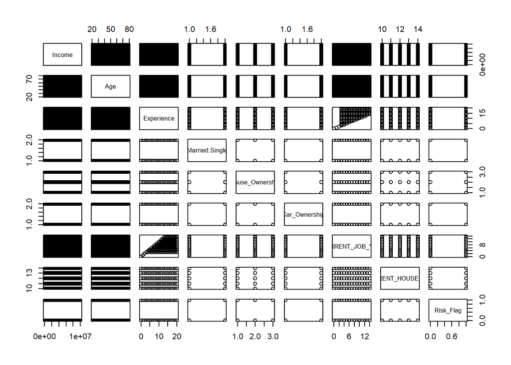

```r
#Box-plot
pairs(loandata)
```

So, let’s look at the correlation of our variables before we dig in deeper and use our assumptions that drove our questions.

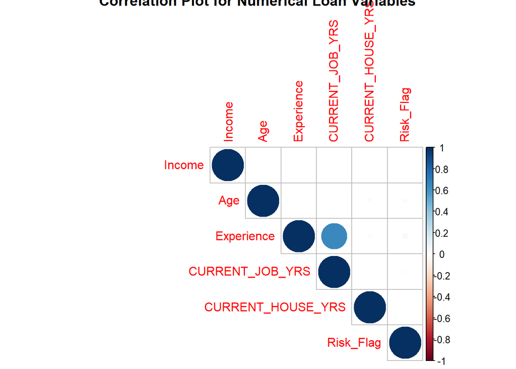

```r
#Import necessary library
library(corrplot)

#Subset out numerical variables for correlation analysis
numericalloan <- subset(loandata, select = c(Income, Age, Experience, CURRENT_JOB_YRS, CURRENT_HOUSE_YRS, Risk_Flag))

#Run correlation
correlation = cor(numericalloan)

xkabledply(correlation)
#Make the plot look presentable
corrplot(correlation, method = 'circle', type = 'upper', title = "Correlation Plot for Numerical Loan Variables")
```

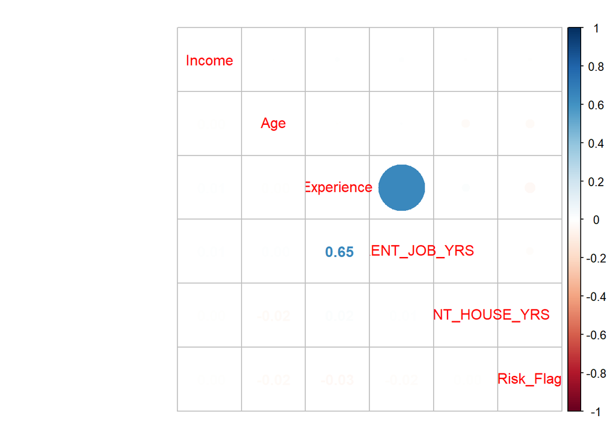

```r
corrplot.mixed(correlation)
```

Examining the correlation plot, we see that Experience and # of years in the job are highly correlated, which is expected. No other variables appear to show strong correlations with each other or with risk flags. We can examine this further as we look into the difference between the the defaulted and non-defaulted populations.

Let’s start with income and examine the boxplots of those who defaulted vs. those who did not.

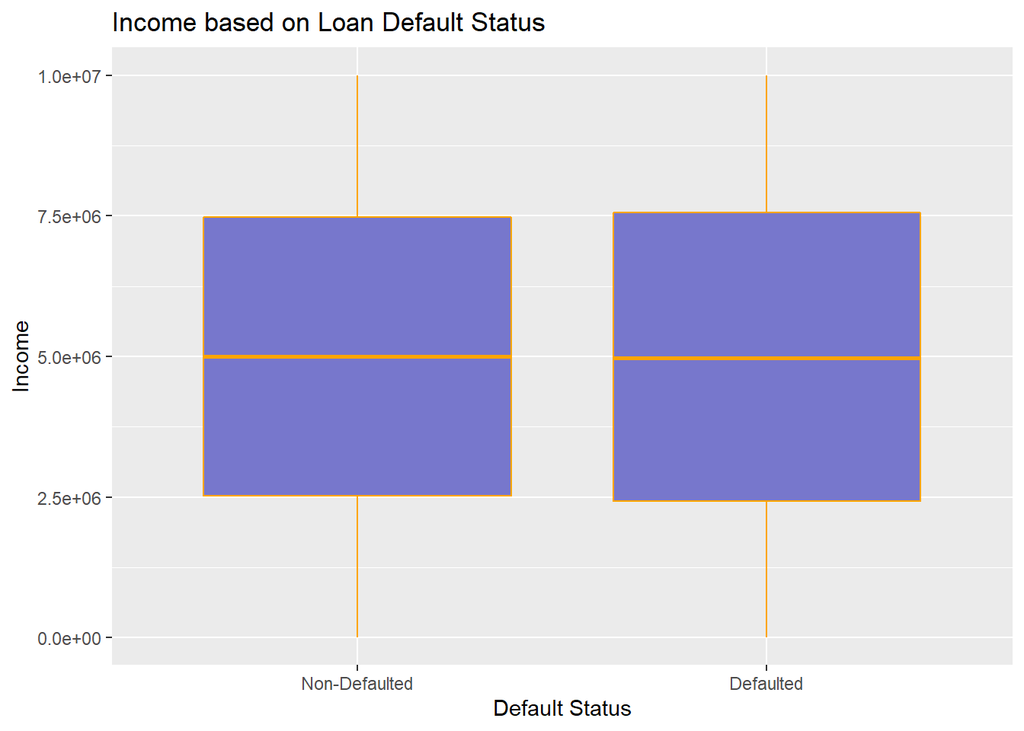

```r
#Import necessary library
library("ggplot2")

#Convert Risk_Flag to factor level
loandata$Risk_Flag <- recode_factor(loandata$Risk_Flag, "0" = "Non-Defaulted", "1" = "Defaulted")

ggplot(loandata, aes(x=Risk_Flag, y=Income)) +
  geom_boxplot( colour="orange", fill="#7777cc", outlier.colour="red", outlier.shape=8, outlier.size=4)+
  labs(title="Income based on Loan Default Status",x="Default Status", y = "Income")
```

Examing these boxplots, we don’t see any inherent difference in the income levels for those who have and haven’t defaulted on their loans. We will still conduct a statistical test later to confirm that income doesn’t differ significantly, but for now we will simply say that it doesn’t appear to differ between our populations.

Let’s now examine home-ownership rates relative to default status.

```r
cont_table_housing <- table(loandata$House_Ownership, loandata$Risk_Flag)
xkabledply(cont_table_housing, title="Contingency table for Home-Ownership vs. Loan Default Status")
```

[output not shown]

Looking at our contingency table, we can see that Renting is clearly the most common form of housing for both populations, followed by owning a home, and lastly by neither owning nor renting their home. It’s a bit tricky to assess proportions from this, but we will later be conducting a chi-square test to determine if the proportions differ between the two populations.

Next, let’s examine marital status vs. loan default status.

```r
cont_table_marriage <- table(loandata$Married.Single, loandata$Risk_Flag)
xkabledply(cont_table_marriage, title="Contingency table for Marriage Status vs. Loan Default Status")
```

[output not shown]

Again, for both those who have defaulted on their loans and those who haven’t, we see that more individuals are single than married. As with home-ownership, it’s tricky to determine by eyeing it, whether the proportions differ significantly. Therefore, we will again conduct a chi-square test later, to assess if these are statistically significant differences in proportion.

Next, let’s assess years of home-ownership against default status. We’ll once again use a box-plot for this.

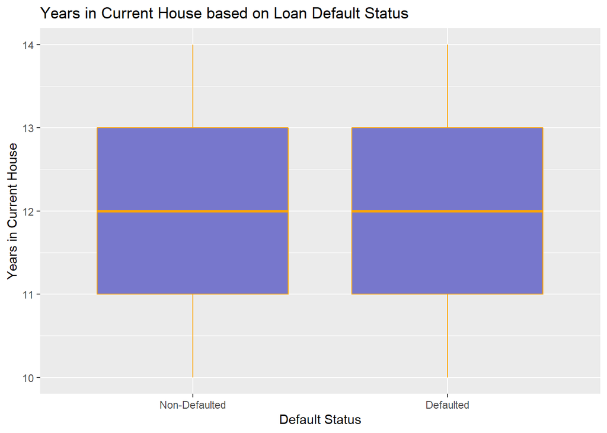

```r
ggplot(loandata, aes(x=Risk_Flag, y=CURRENT_HOUSE_YRS)) +
  geom_boxplot( colour="orange", fill="#7777cc", outlier.colour="red", outlier.shape=8, outlier.size=4)+
  labs(title="Years in Current House based on Loan Default Status",x="Default Status", y = "Years in Current House")
```

As before with income, we see that the boxplots appear almost identical. We’ll have to use a test to determine if there is a statistically significant difference between the years in housing for those who have defaulted on their loans and those who haven’t.

Next, we’ll assess both experience in the current job and overall job experience relative to loan default status.

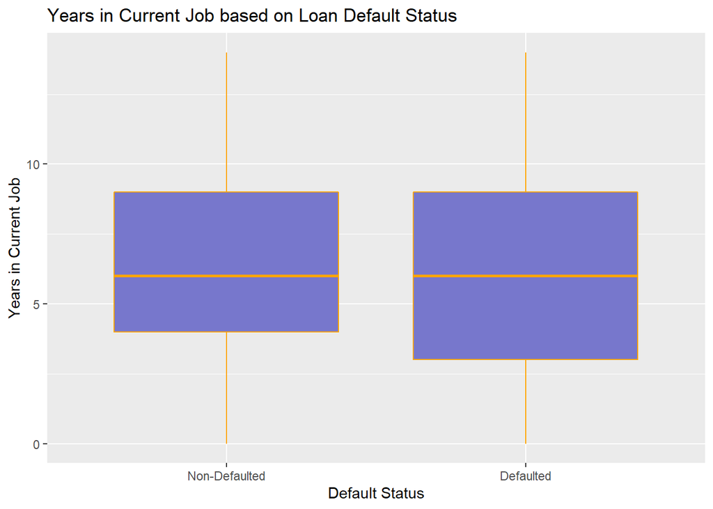

```r
ggplot(loandata, aes(x=Risk_Flag, y=CURRENT_JOB_YRS)) +
  geom_boxplot( colour="orange", fill="#7777cc", outlier.colour="red", outlier.shape=8, outlier.size=4)+
  labs(title="Years in Current Job based on Loan Default Status",x="Default Status", y = "Years in Current Job")
```

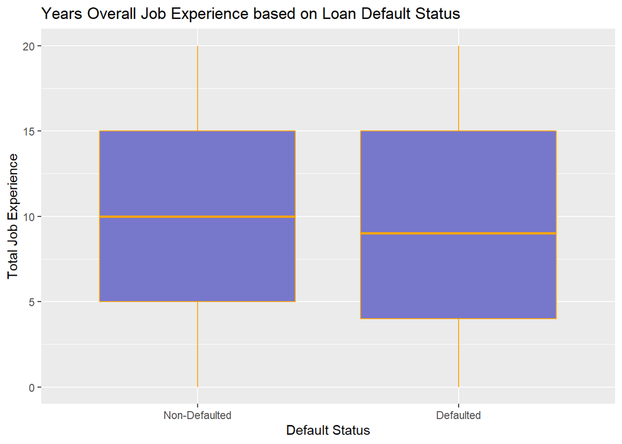

```r
ggplot(loandata, aes(x=Risk_Flag, y=Experience)) +
  geom_boxplot( colour="orange", fill="#7777cc", outlier.colour="red", outlier.shape=8, outlier.size=4)+
  labs(title="Years Overall Job Experience based on Loan Default Status",x="Default Status", y = "Total Job Experience")
```

Although the top end of the boxplots look relatively similar, it’s important to note that in both current job experience and overall job experience, the lower bound of the IQR for defaulted customers, is lower than for non-defaulted customers. As with all of our other variables, we’ll conduct testing to determine if this is a significant difference between defaulted and non-defaulted customers.

Lastly, we’ll assess the age of customers relative to their loan default status

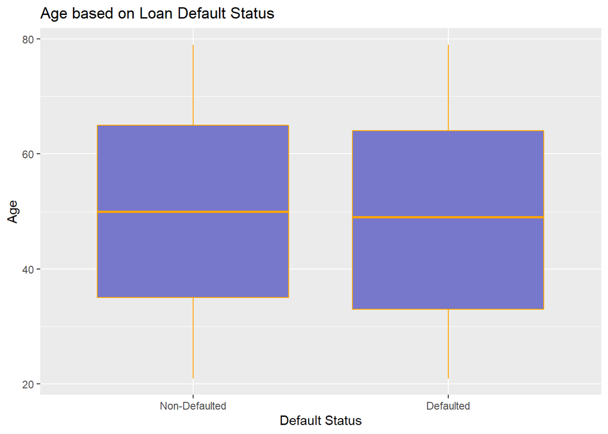

```r
ggplot(loandata, aes(x=Risk_Flag, y=Age)) +
  geom_boxplot( colour="orange", fill="#7777cc", outlier.colour="red", outlier.shape=8, outlier.size=4)+
  labs(title="Age based on Loan Default Status",x="Default Status", y = "Age")
```

Although the difference appears subtle, we can see that the boxplot for Defaulted customers is slightly lower than for non-defaulted customers. This would imply, potentially, that defaulted customers are slightly younger than non-defaulted customers. We’ll again conduct a test to confirm if this hypothesis is correct.

Although we didn’t see any indication of outliers or NA values in our boxplots and preliminary data checks, it’s still worthwhile to confirm that before we proceed with our analysis.

### Checking for NA values and outliers

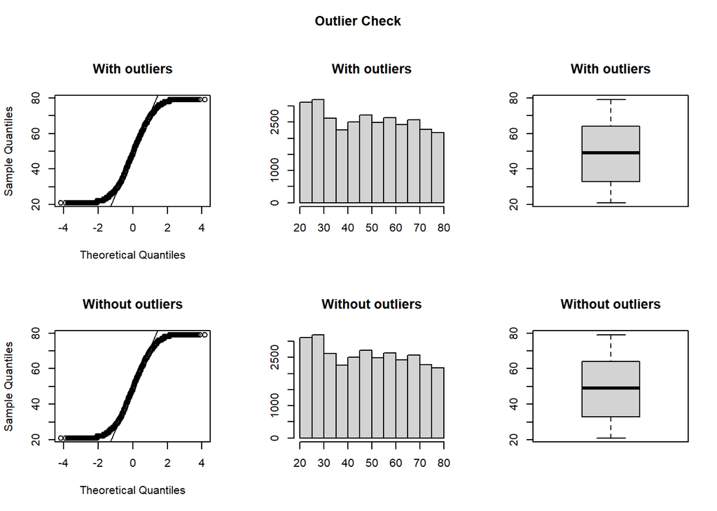

```r
str(loandata)
sum(is.na(loandata$Age))
sum(is.na(loandata$Income))
sum(is.na(loandata$Experience))
sum(is.na(loandata$Married.Single))
sum(is.na(loandata$House_Ownership))
sum(is.na(loandata$Car_Ownership))
sum(is.na(loandata$CURRENT_HOUSE_YRS))
sum(is.na(loandata$CURRENT_JOB_YRS))
sum(is.na(loandata$Income))

outlierKD2(defaulted, Age, rm=TRUE, boxplt=TRUE, histogram=TRUE, qqplt=TRUE)
```

[output not shown]

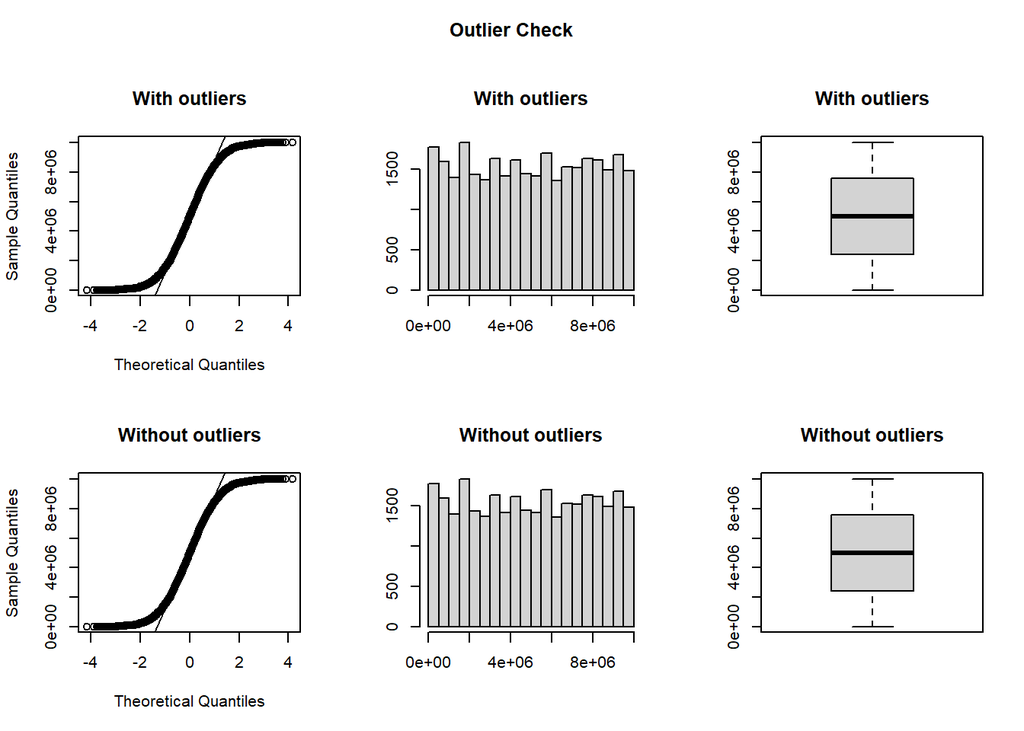

```r
outlierKD2(defaulted, Income, rm=TRUE, boxplt=TRUE, histogram=TRUE, qqplt=TRUE)
```

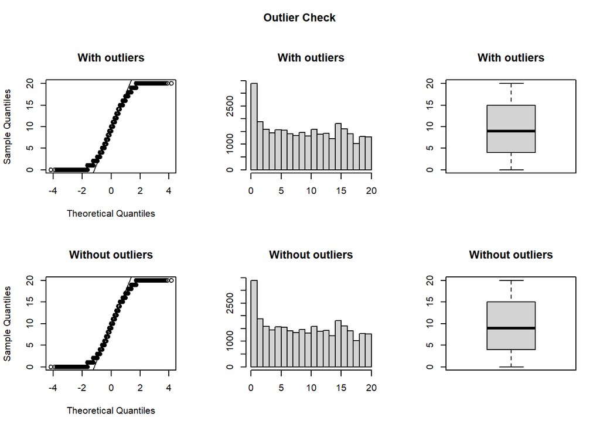

```r
outlierKD2(defaulted, Experience, rm=TRUE, boxplt=TRUE, histogram=TRUE, qqplt=TRUE)
```

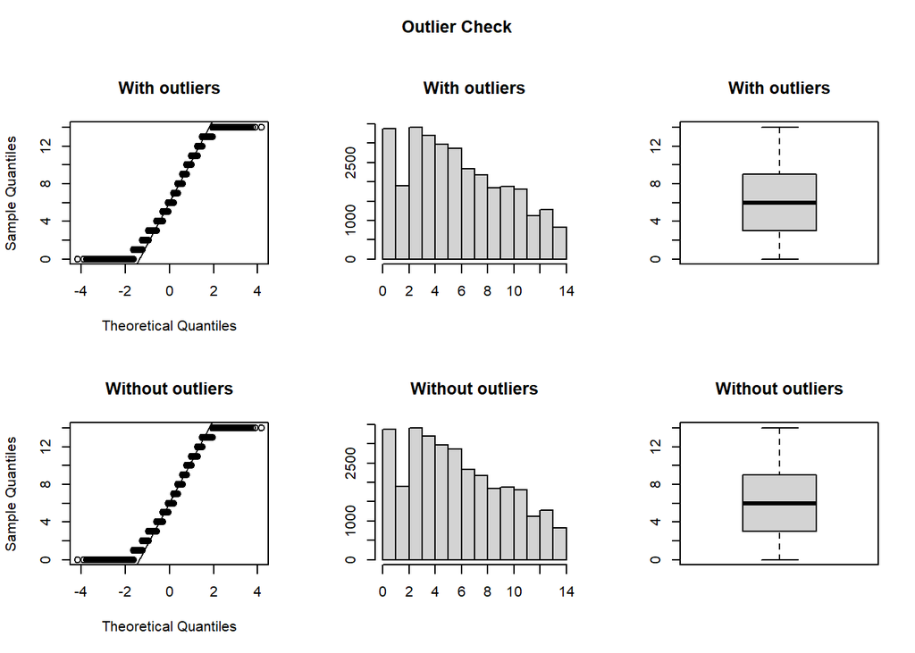

```r
outlierKD2(defaulted, CURRENT_JOB_YRS, rm=TRUE, boxplt=TRUE, histogram=TRUE, qqplt=TRUE)
```

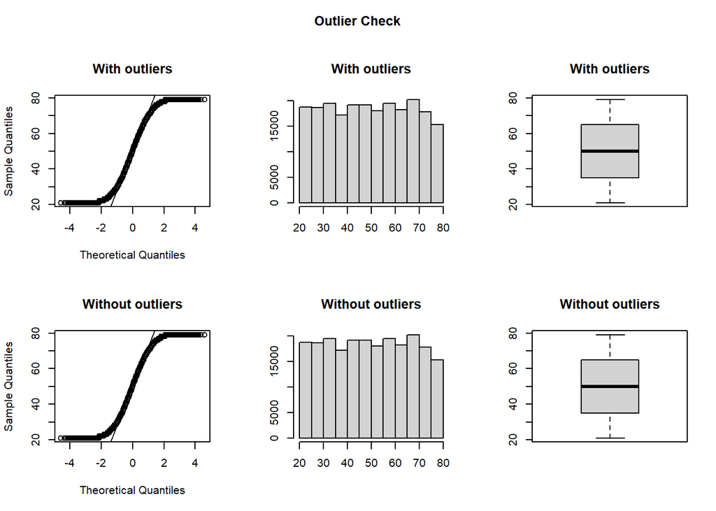

```r
outlierKD2(not_defaulted, Age, rm=TRUE, boxplt=TRUE, histogram=TRUE, qqplt=TRUE)
```

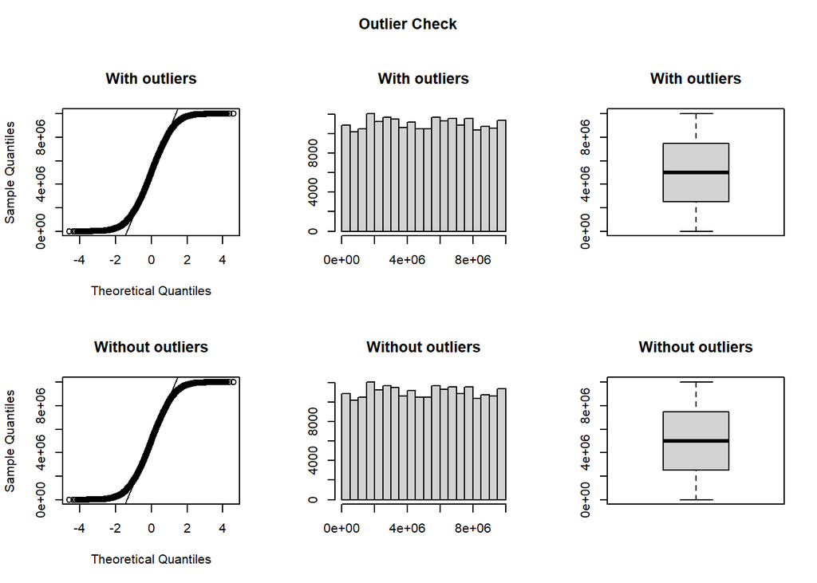

```r
outlierKD2(not_defaulted, Income, rm=TRUE, boxplt=TRUE, histogram=TRUE, qqplt=TRUE)
```

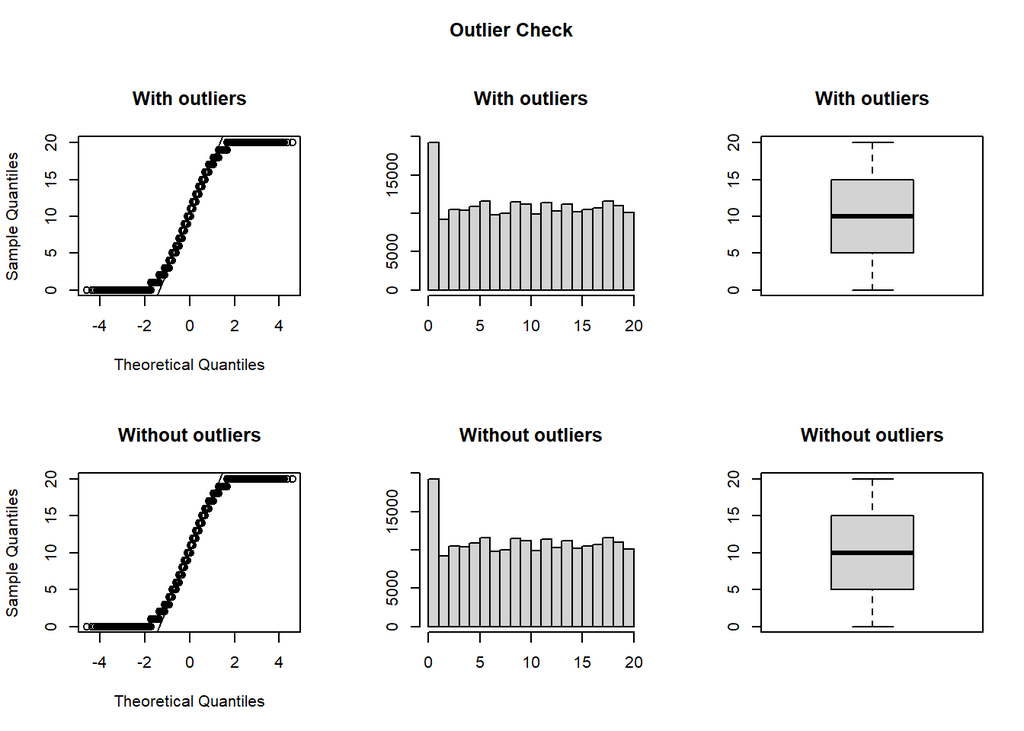

```r
outlierKD2(not_defaulted, Experience, rm=TRUE, boxplt=TRUE, histogram=TRUE, qqplt=TRUE)
```

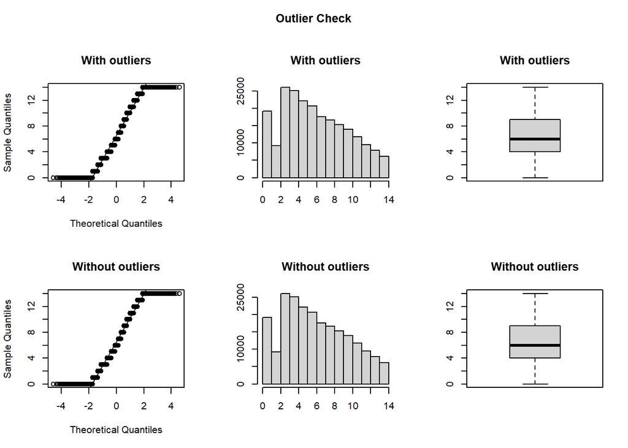

```r
outlierKD2(not_defaulted, CURRENT_JOB_YRS, rm=TRUE, boxplt=TRUE, histogram=TRUE, qqplt=TRUE)
```

Before we get to our statistical testing, let’s confirm our quantitative variables all follow the required normality assumptions. To do that, we’ll go ahead and examine a histogram and Q-Q Plot for each variables, make a visual assessment of normality to confirm our assumptions. We will conduct this assessment separately for Defaulted and Non-Defaulted customers to ensure that each population follows the normal distribution.

## Assesment non-defaulted population.

We’ll go ahead and start with our population that did not default on their loans before moving onto the population that did default.

### Analysis for Age

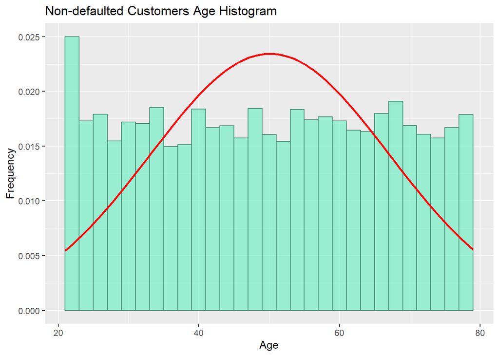

```r
#str(loandata)


ggplot(data=not_defaulted, aes(Age)) +
  geom_histogram(aes(y=..density..), binwidth = 2,
                 col="aquamarine4",
                 fill="aquamarine2",
                 alpha = .7) +
  labs(title="Non-defaulted Customers Age Histogram") +
  stat_function(fun=dnorm, lwd = 1, col = 'red', args = list(mean = mean(not_defaulted$Age, na.rm = TRUE), sd = sd(not_defaulted$Age, na.rm = TRUE))) +
  labs(x="Age", y="Frequency")
```

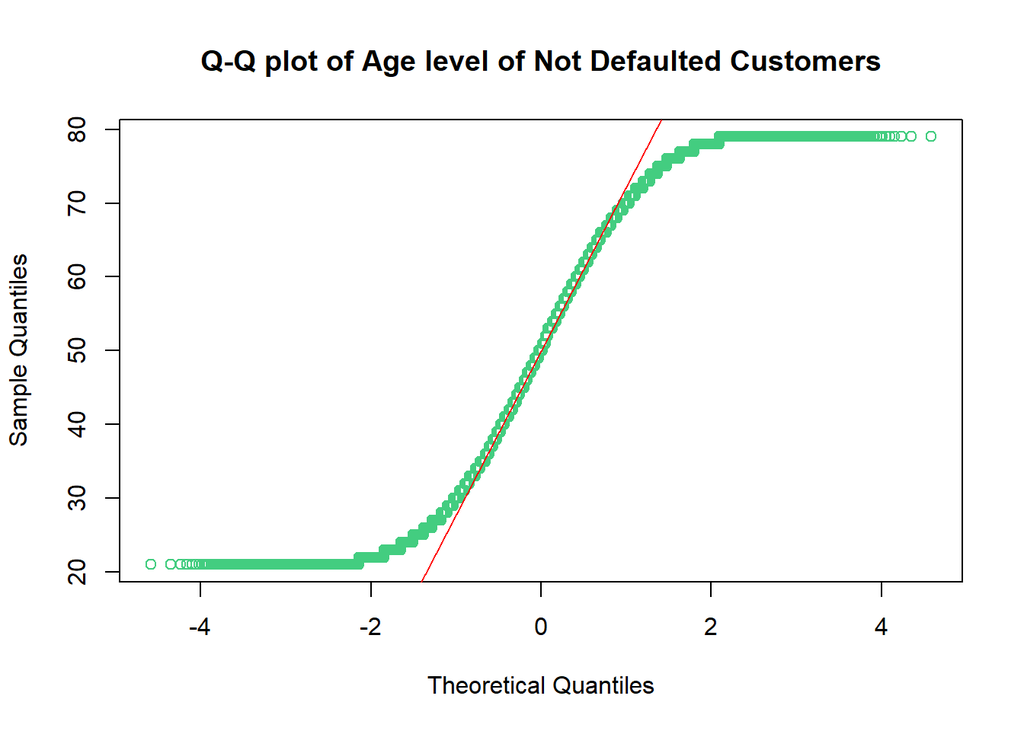

```r
qqnorm(not_defaulted$Age, main="Q-Q plot of Age level of Not Defaulted Customers", col = 'seagreen3')
qqline(not_defaulted$Age, col = 'red')
```

```r
##shapiro.test(not_defaulted$Age) sample size to big to conduct a shapiro test, not necessary
```

### Analysis for Income

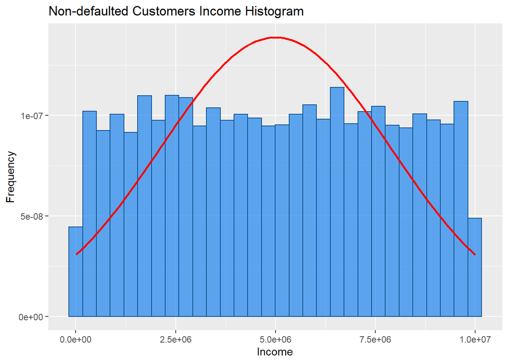

```r
# ggplot(not_defaulted, aes(y=Income)) +
#   geom_boxplot() +
#   geom_boxplot( colour="orange", fill="#7777cc", outlier.colour="red", outlier.shape=8, outlier.size=4) +
#   labs(title="Not_Defaulted Customer Income boxplot ",x="", y = "weight (lbs)")

ggplot(data=not_defaulted, aes(Income)) +
  geom_histogram(aes(y=..density..),
                 col="dodgerblue4",
                 fill="dodgerblue2",
                 alpha = .7) +
  labs(title="Non-defaulted Customers Income Histogram") +
  stat_function(fun=dnorm, lwd = 1, col = 'red', args = list(mean = mean(not_defaulted$Income, na.rm = TRUE), sd = sd(not_defaulted$Income, na.rm = TRUE))) +
  labs(x="Income", y="Frequency")
```

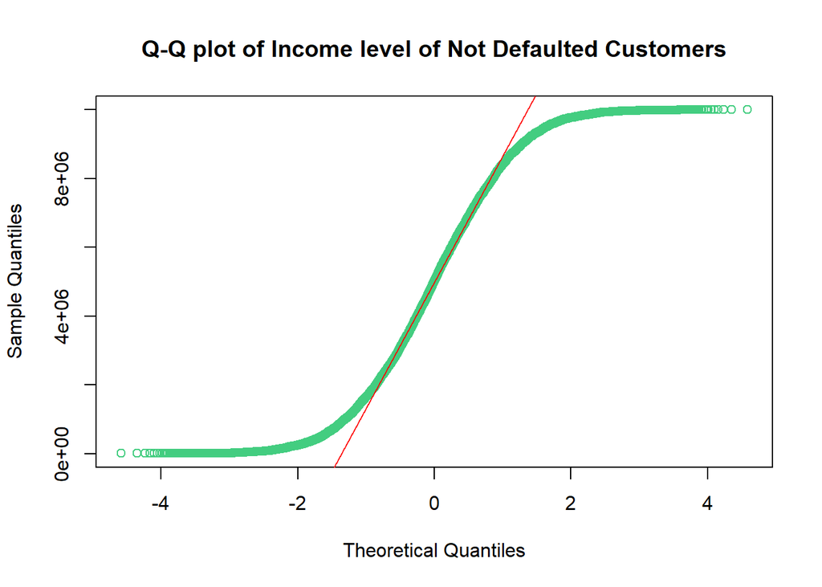

```r
qqnorm(not_defaulted$Income, main="Q-Q plot of Income level of Not Defaulted Customers", col = 'seagreen3')
qqline(not_defaulted$Income, col = 'red')
```

Again, our histogram shows a relatively uniform distribution when we have sufficiently large bin sizes, which is confirmed with the heavy tails seen in the QQ-plot.

### Analysis for Experience

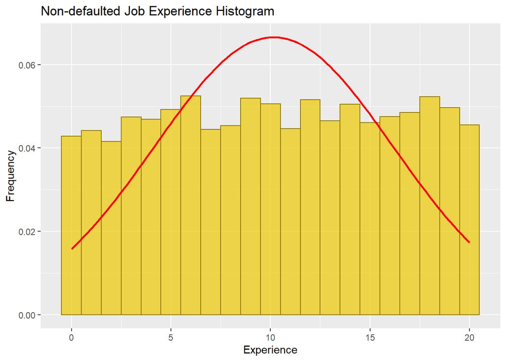

```r
#str(loandata)


ggplot(data=not_defaulted, aes(Experience)) +
  geom_histogram(aes(y=..density..), binwidth = 1,
                 col="gold4",
                 fill="gold2",
                 alpha = .7) +
  stat_function(fun=dnorm, lwd = 1, col = 'red', args = list(mean = mean(not_defaulted$Experience), sd = sd(not_defaulted$Experience))) +
  labs(title="Non-defaulted Job Experience Histogram") +
  labs(x="Experience", y="Frequency")
```

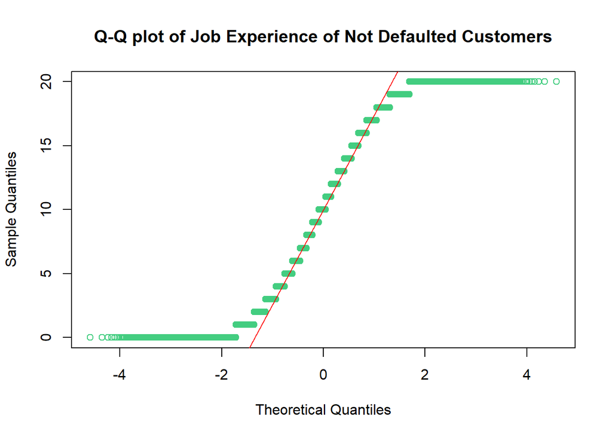

```r
qqnorm(not_defaulted$Experience, main="Q-Q plot of Job Experience of Not Defaulted Customers", col = 'seagreen3')
qqline(not_defaulted$Experience, col = 'red')
```

Again, our histogram is showing a uniform distribution, and our QQ-Plot confirms it. Of note, on the QQ-plot is the discrete nature of the data. Because we’re working in years of experience, it would not make sense to have the data in decimals, but it is clearly a ratio type, so we should not turn this into a categorical variable.

### Analysis for Current House Years

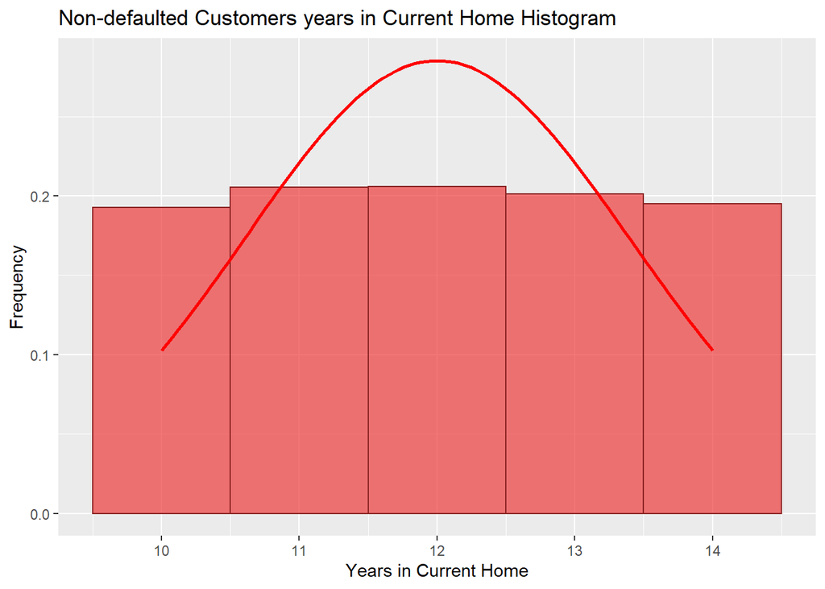

```r
ggplot(data=not_defaulted, aes(CURRENT_HOUSE_YRS)) +
  geom_histogram(aes(y=..density..), binwidth = 1,
                 col="brown4",
                 fill="brown2",
                 alpha = .7) +
  stat_function(fun=dnorm, lwd = 1, col = 'red', args = list(mean = mean(not_defaulted$CURRENT_HOUSE_YRS, na.rm = TRUE), sd = sd(not_defaulted$CURRENT_HOUSE_YRS, na.rm = TRUE))) +
  labs(title="Non-defaulted Customers years in Current Home Histogram") +
  labs(x='Years in Current Home', y="Frequency")
```

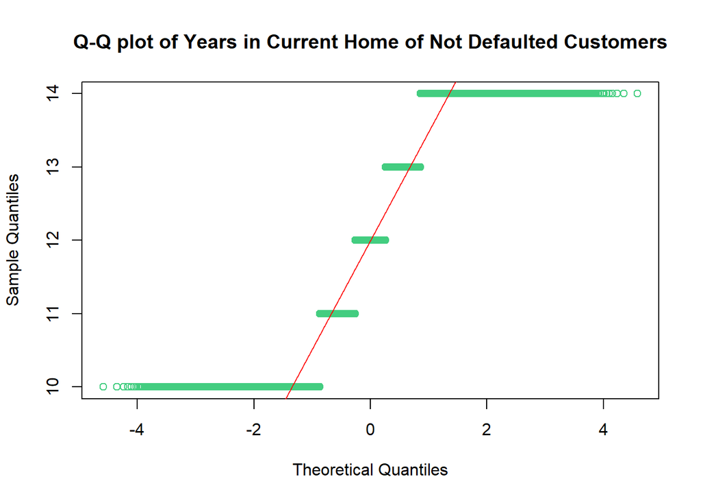

```r
qqnorm(not_defaulted$CURRENT_HOUSE_YRS, main="Q-Q plot of Years in Current Home of Not Defaulted Customers", col = 'seagreen3')
qqline(not_defaulted$CURRENT_HOUSE_YRS, col = 'red')
```

As with years of job experience, we see the data is uniformly distributed and that, by the nature of the variable, the QQ-plot shows a discrete pattern. Again, for our analysis purposes, this is a ratio data type and we will want to understand how default status changes for a 1 year change in years in current house will impact default status. Therefore, we will keep this as a continuous variable for our purposes.

### Analysis for Current Job Years

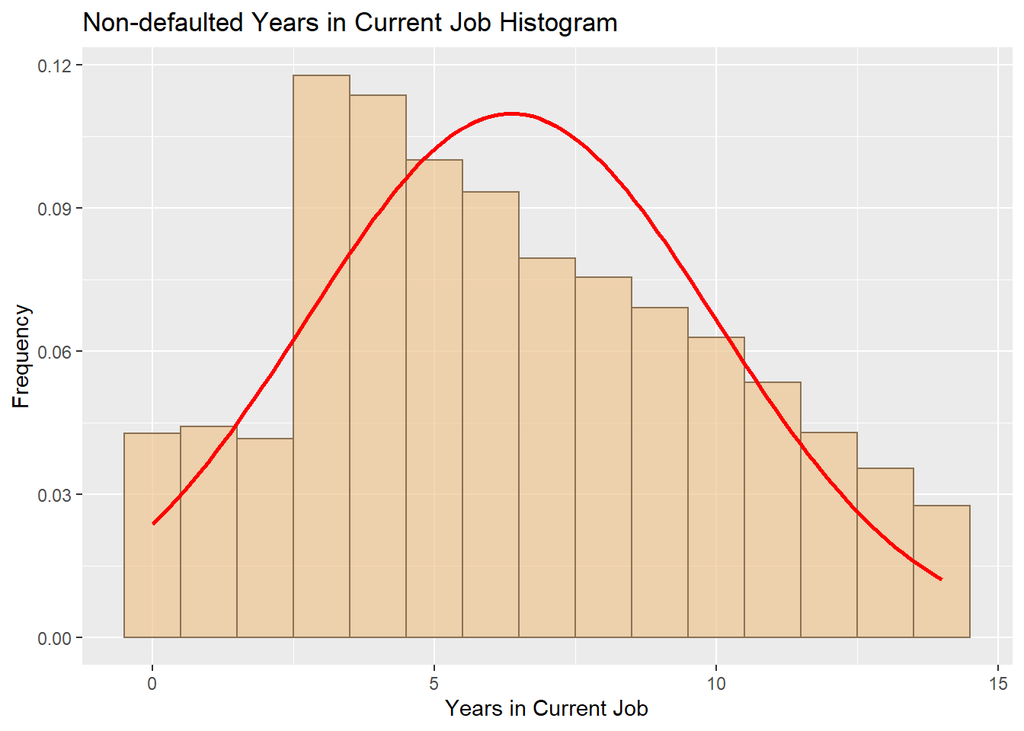

```r
ggplot(data=not_defaulted, aes(CURRENT_JOB_YRS)) +
  geom_histogram(aes(y=..density..), binwidth = 1,
                 col="burlywood4",
                 fill="burlywood2",
                 alpha = .7) +
  labs(title="Non-defaulted Years in Current Job Histogram") +
  stat_function(fun=dnorm, lwd = 1, col = 'red', args = list(mean = mean(not_defaulted$CURRENT_JOB_YRS, na.rm = TRUE), sd = sd(not_defaulted$CURRENT_JOB_YRS, na.rm = TRUE))) +
  labs(x="Years in Current Job", y="Frequency")
```

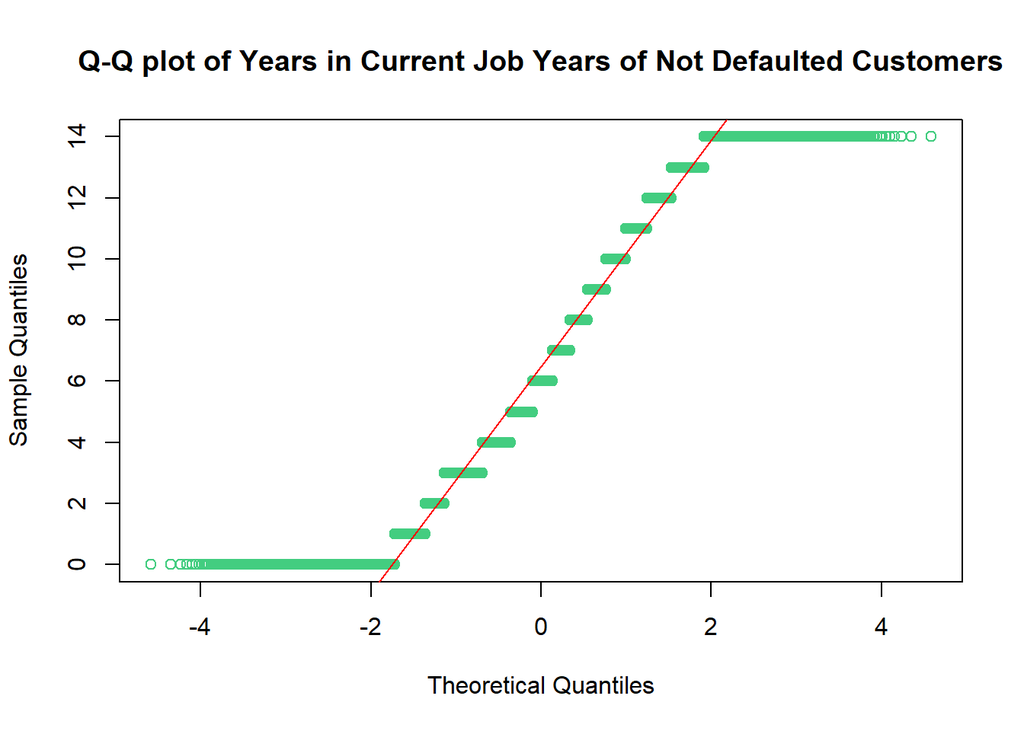

```r
qqnorm(not_defaulted$CURRENT_JOB_YRS, main="Q-Q plot of Years in Current Job Years of Not Defaulted Customers", col = 'seagreen3')
qqline(not_defaulted$CURRENT_JOB_YRS, col = 'red')
```

Different from our other variables, Years in Current Job is showing a semi-exponential distribution with a uniform left tail. The QQ-plot backs up these assumptions with the normal middle of the graph, and weighted tails. As mentioned earlier, based on our inference using the sample average, we will still be working with a normally distributed variable based on Central Limit Theorem.

## Assesment defaulted population.

Now, we will examine the same variables for the defaulted population. The key here is that the defaulted population should follow the same distribution types as we saw for the non-defaulted population.

### Analysis for Age

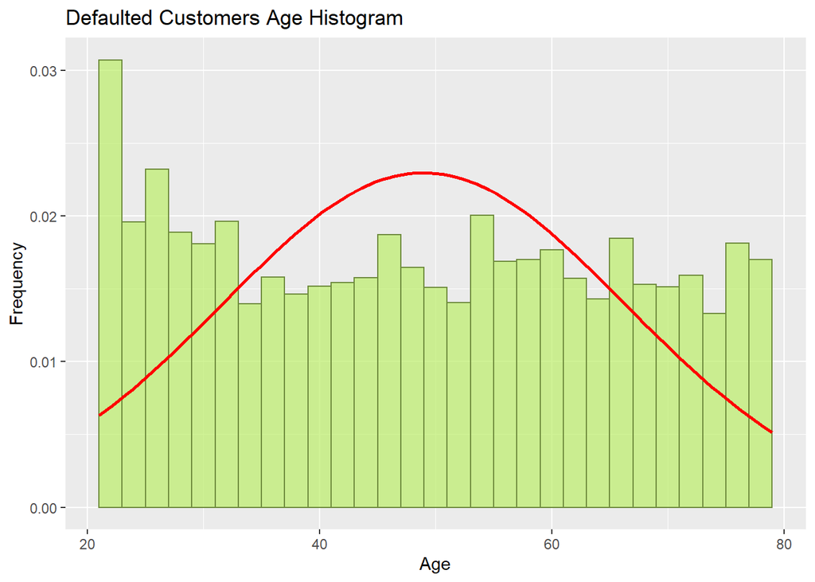

```r
ggplot(data=defaulted, aes(Age)) +
  geom_histogram(aes(y=..density..),
                 binwidth = 2,
                 col="darkolivegreen4",
                 fill="darkolivegreen2",
                 alpha = .7) +
  stat_function(fun=dnorm, lwd = 1, col = 'red', args = list(mean = mean(defaulted$Age, na.rm = TRUE), sd = sd(defaulted$Age, na.rm = TRUE))) + # opacity
  labs(title="Defaulted Customers Age Histogram") +
  labs(x="Age", y="Frequency")
```

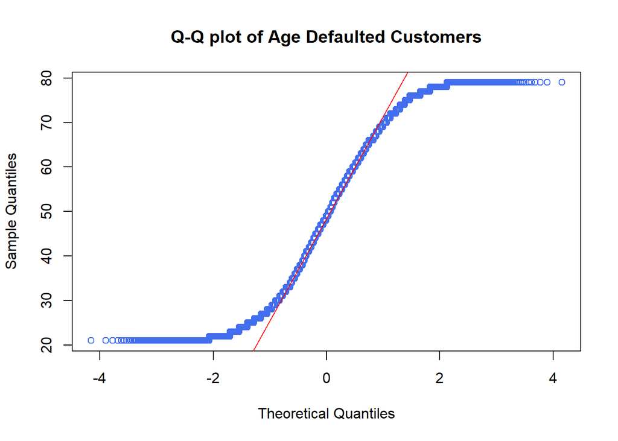

```r
qqnorm(defaulted$Age, main="Q-Q plot of Age Defaulted Customers", col = 'royalblue2' )
qqline(defaulted$Age, col = 'red')
```

The histogram shows a semi-uniform distribution, which is what we would expect. The distribution looks less “smooth” than the non-defaulted population, which is expected due to the skewed sample sizes within each population. Our QQ-plot again agrees with our assessment, with a fairly normal middle of the QQ-plot and heavy tails on either side.

### Analysis for Income

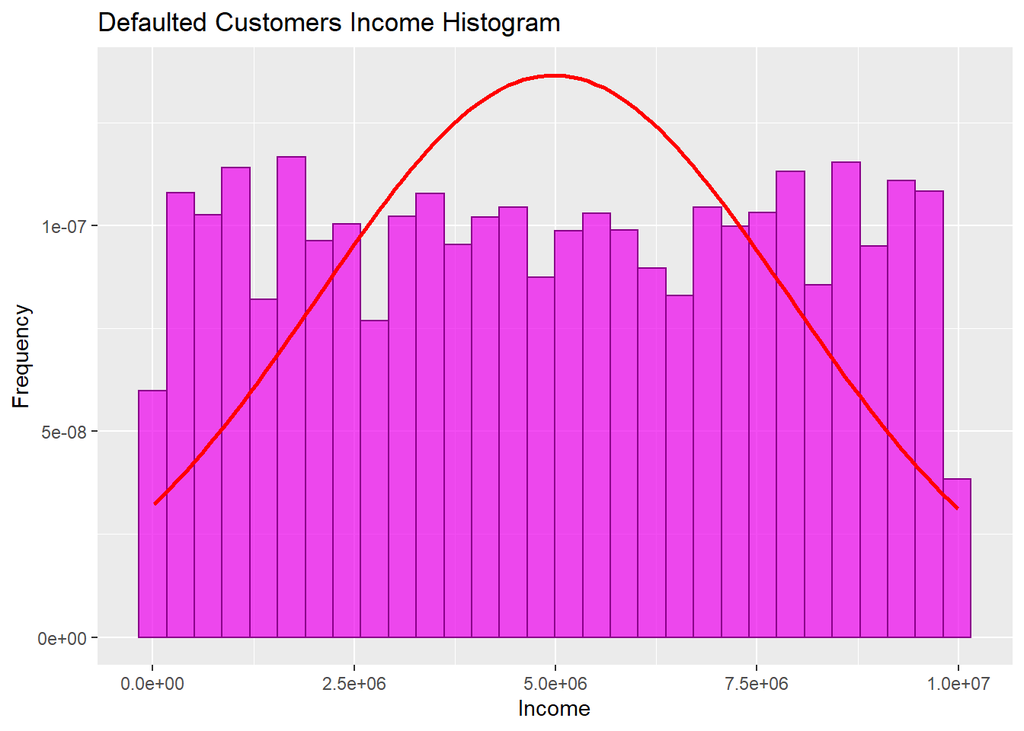

```r
ggplot(data=defaulted, aes(Income)) +
  geom_histogram(aes(y=..density..),
                 col="magenta4",
                 fill="magenta2",
                 alpha = .7) +
  stat_function(fun=dnorm, lwd = 1, col = 'red', args = list(mean = mean(defaulted$Income, na.rm = TRUE), sd = sd(defaulted$Income, na.rm = TRUE))) +
  labs(title="Defaulted Customers Income Histogram") +
  labs(x="Income", y="Frequency")
```

[figure not shown]

```r
qqnorm(defaulted$Income, main="Q-Q plot of Income level of Not Defaulted Customers", col = 'royalblue2')
qqline(defaulted$Income, col = 'red')
```

As expected, income again shows a uniform distribution and our QQ-plot agrees. This is what we saw with our non-defaulted population, so the two sample buckets match in distribution.

### Analysis for Experience

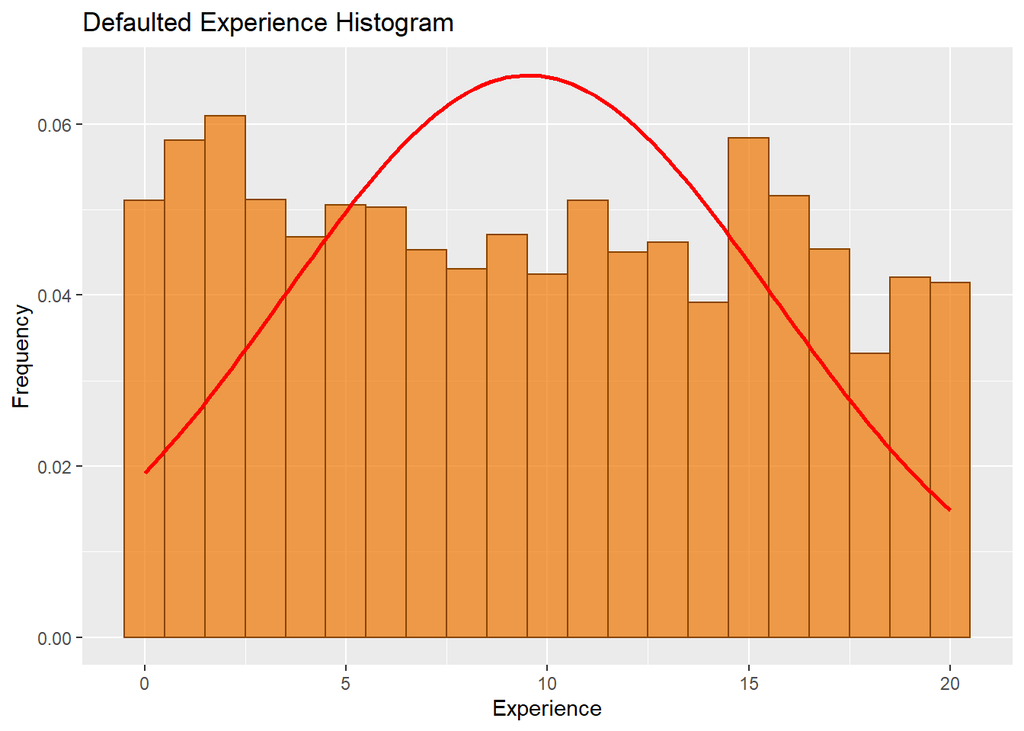

```r
#str(loandata)
ggplot(data=defaulted, aes(Experience)) +
  geom_histogram(aes(y=..density..),
                 binwidth = 1,
                 col="darkorange4",
                 fill="darkorange2",
                 alpha = .7) +
  stat_function(fun=dnorm, lwd = 1, col = 'red', args = list(mean = mean(defaulted$Experience, na.rm = TRUE), sd = sd(defaulted$Experience, na.rm = TRUE))) +
  labs(title="Defaulted Experience Histogram") +
  labs(x="Experience", y="Frequency")
```

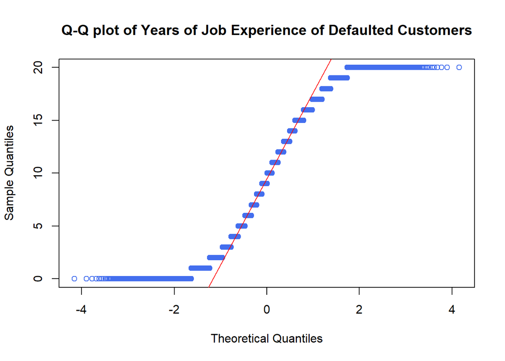

```r
qqnorm(defaulted$Experience, main="Q-Q plot of Years of Job Experience of Defaulted Customers", col = 'royalblue2')
qqline(defaulted$Experience, col = 'red')
```

Once again, we see a uniform distribution, as expected, which agrees with our non-defaulted sample population. Further, our QQ-plot again shows this with the heavily weighted tails.